# Code Through

Robert M. Trehern

05 October, 2020

As I was looking for a topic for this code through assignment, I came across an article, referenced below, discussing an add-in called ‘esquisse’ that allows users to ‘drag-and-drop’ data fields to generate plots using ‘ggplot2’. I was intrigued by the 10-15 second demonstration video embedded in the article, so I thought I would give it a try.

#### Install required packages:

As with any other R Package, you must first install ‘esquisse’. Once you have it installed in RStudio, you must call upon it in your document by using the “library()” function. It’s important to note that for ‘esquisse’ to work properly, you must also use ‘ggplot2’ and ‘shiny’. The reason for this is because the code exported from ‘esquisse’ relies on functions in these two associated packages.

```r
library(esquisse)
library(ggplot2)
library(shiny)
```

#### Load a data set

‘esquisse’ works with any data set you can use in RStudio. For the purposes of this demonstration, I decided to use the data set “faithful” which depicts the eruptions and wait times associated with the Old Faithful geyser.

```r
data("faithful")
```

#### How to use ‘esquisse’:

This add-in was very easy to use. The single function below is all that is required. When you run this chunk, a pop-up will be generated and you do the rest in the pop-up. Below, I have added a series of screen shots and descriptions to help illustrate how it works.

```r
esquisse::esquisser()
```

```
##
## Listening on http://127.0.0.1:5106
```

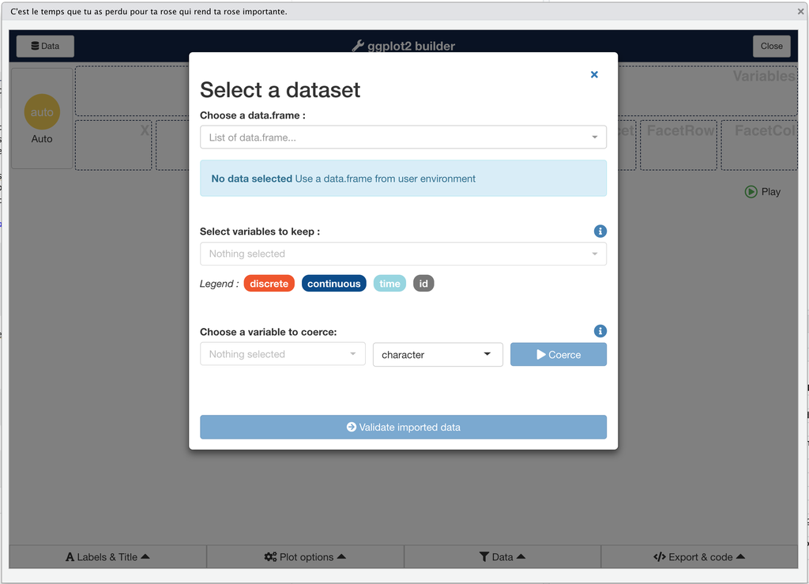

This is the initial screen you will see when you run the function above. It is a pop-up screen from RStudio.

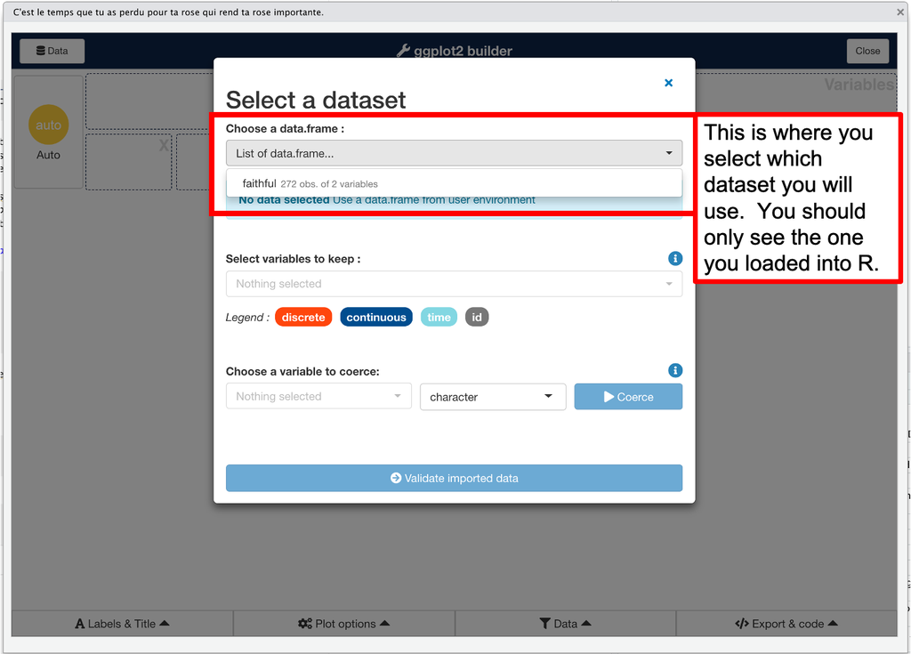

Select your dataset.

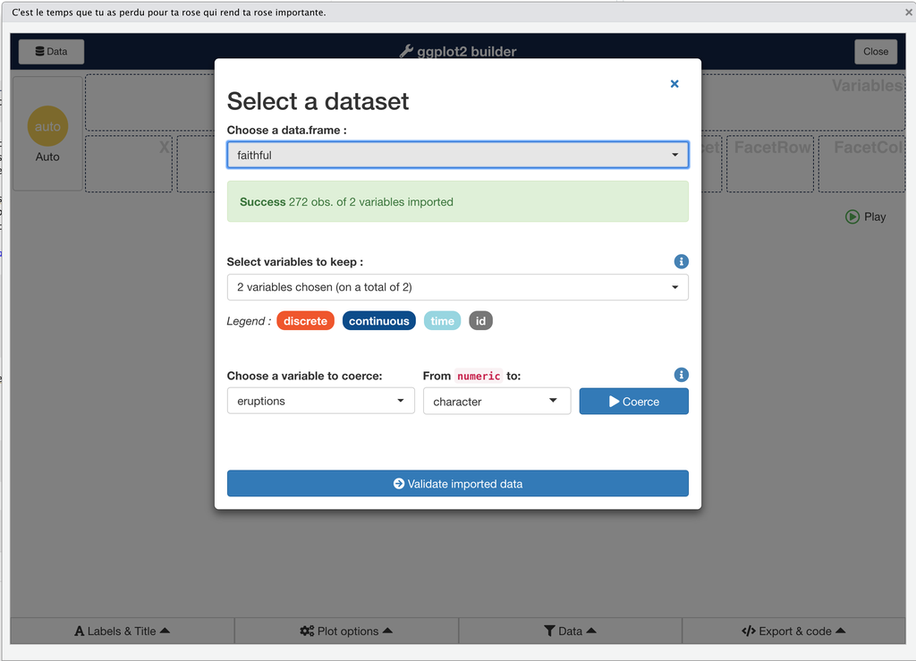

This is what you should see if your dataset was imported successfully. If it appears in the dropdown list, then you have done it correctly.

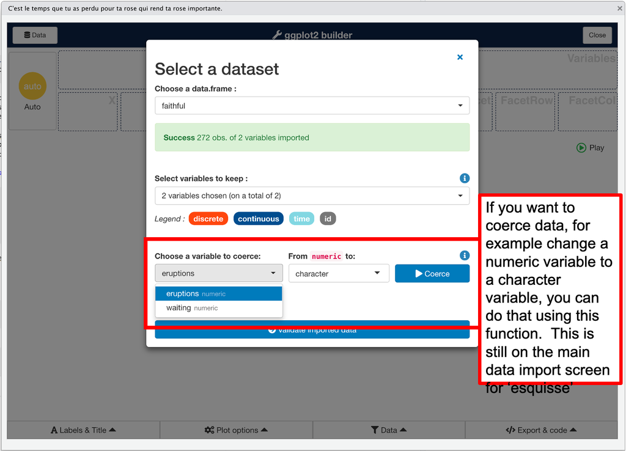

This section allows you to coerce data if you want to. For example, you can change a numeric variable to a character variable prior to using the add-in. The type of variable may affect the manner in which it can be plotted.

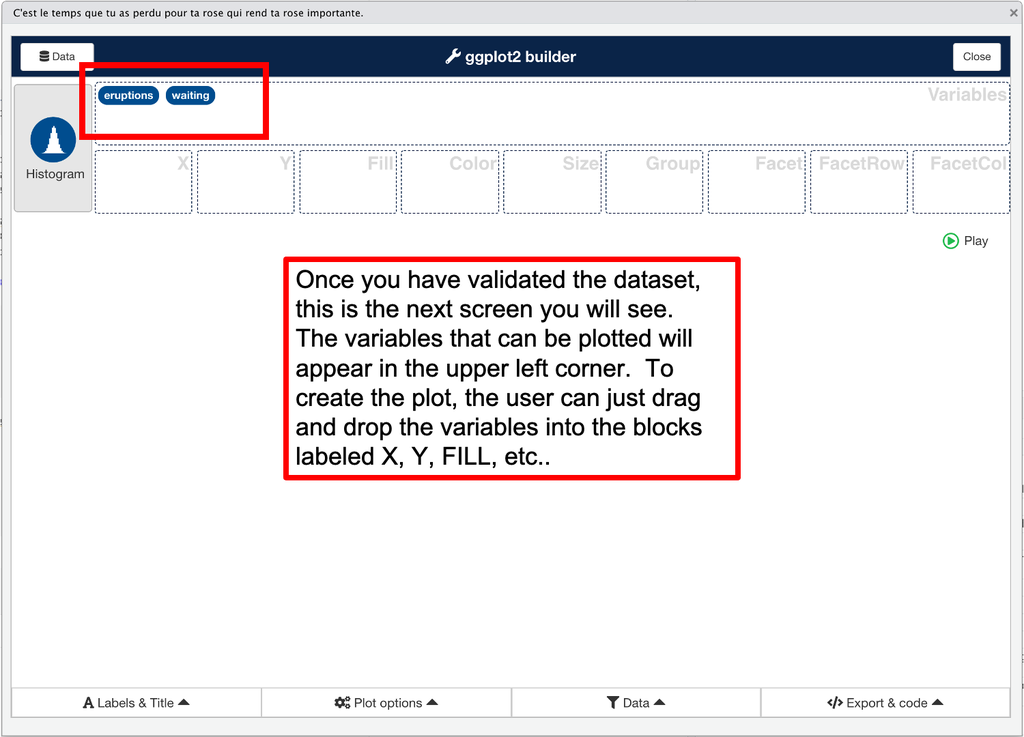

The main work screen.

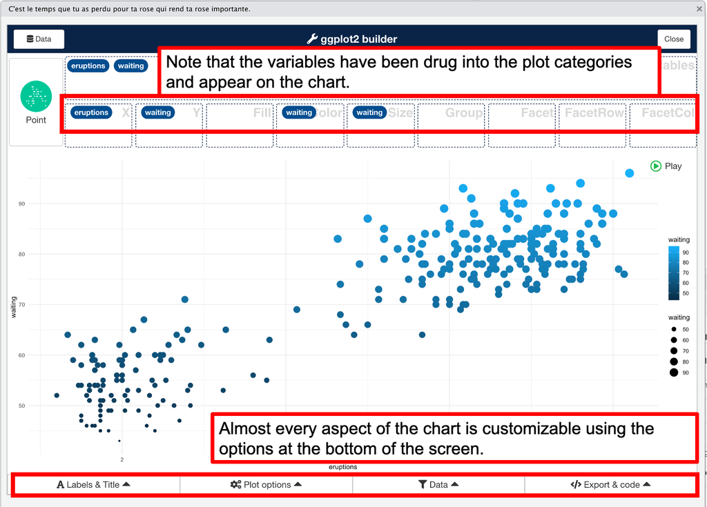

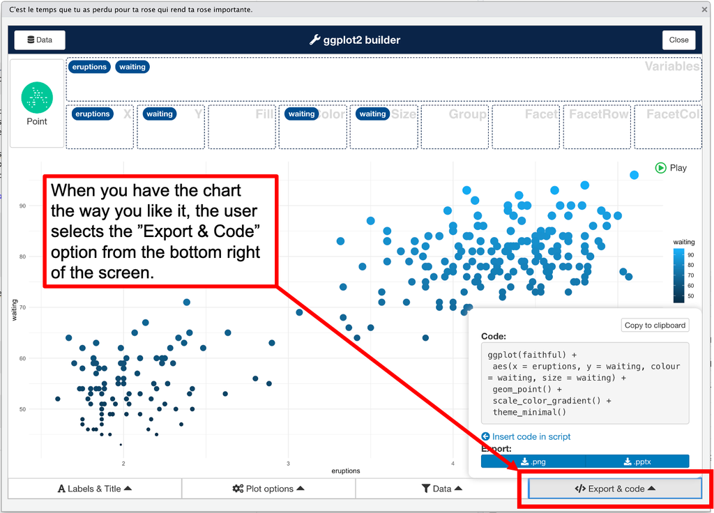

This is where ‘esquisse’ is a huge time saver. Once you have your chart the way you like it, at the bottom right hand corner of the screen, there is a button to export the code. Simply click that button, and the add-in creates the code required for ‘ggplot2’ and adds it back in to RStudio into your project.

[figure not shown]

At this point you are done using the add-in and can close out of it. Everything beyond this point was done back in RStudio.

#### The exported code back in RStudio:

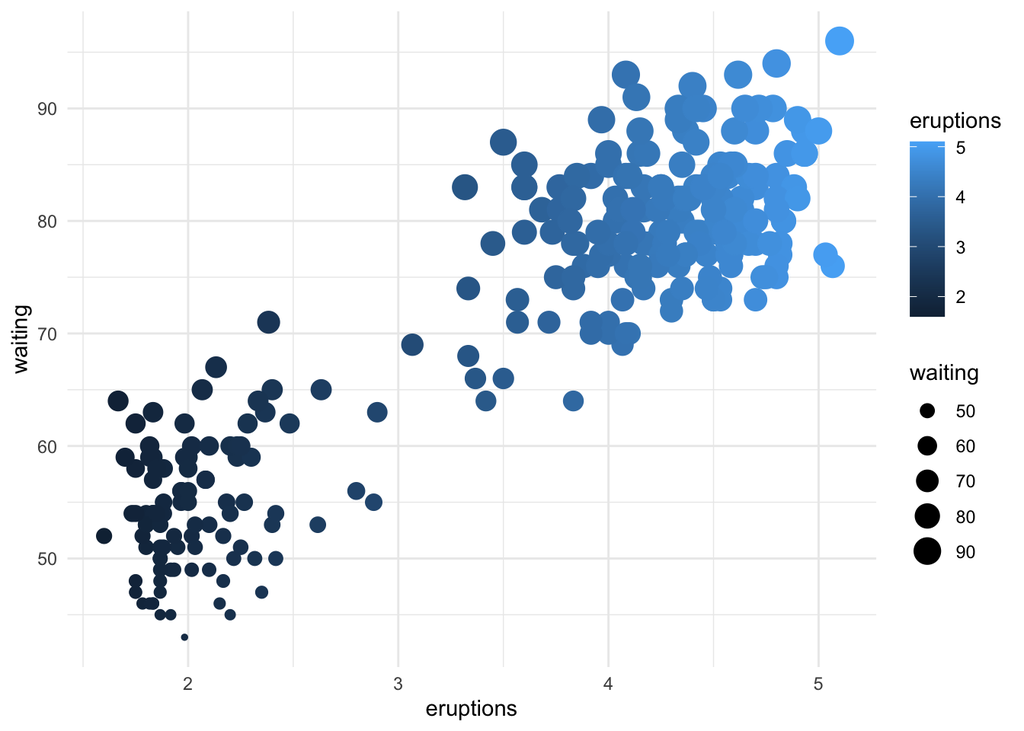

```r
ggplot(faithful) +
 aes(x = eruptions, y = waiting, colour = eruptions, size = waiting) +
 geom_point() +
 scale_color_gradient() +
 theme_minimal()
```

For me, it was far easier to work with the data in the add-in screen and then just have the program generate the code. I’m sure this add-in has its limitations, but for simple data sets, it made really quick work of plotting things out.

#### References:

Arora, Akshat. (2019). “8 Useful R Packages for Data Science You Aren’t Using (But Should!)” Web article: Analytics Vidhya. Retrieved from: https://www.analyticsvidhya.com/blog/2019/04/8-useful-r-packages-data-science/